# Group Project 1

Group 2_Cameron Mangione_Jacob Wilson_JackLichwa_Ahrial Young

2025-10-26

```r
library(dplyr)
```

```r
library(ggplot2)
library(nycflights13)
library(readr)
library(curl)
library(tidyr)
library(fivethirtyeight)
library(tidyverse)
library(resampledata3)
library(readxl)
```

## Initial Data Cleaning + Merging (All)

#### Our data cleaning consisted of filtering our flights dataframe to only include United Airlines flights, removing all NA values from our weather and flights dataframes, and then conducting an inner join of the flights and weather datasets, based on year, month, day, hour, and origin.

#### Additionally, we also created a column for late flights, which consisted of departure delays greater than 0 minutes.

#### We defined a function for some of our permutation tests to run, so the permutation here is a blank permutation test to use throughout our code.

```r
weather
```

```
## # A tibble: 26,115 × 15
##    origin  year month   day  hour  temp  dewp humid wind_dir wind_speed
##    <chr>  <int> <int> <int> <int> <dbl> <dbl> <dbl>    <dbl>      <dbl>
##  1 EWR     2013     1     1     1  39.0  26.1  59.4      270      10.4
##  2 EWR     2013     1     1     2  39.0  27.0  61.6      250       8.06
##  3 EWR     2013     1     1     3  39.0  28.0  64.4      240      11.5
##  4 EWR     2013     1     1     4  39.9  28.0  62.2      250      12.7
##  5 EWR     2013     1     1     5  39.0  28.0  64.4      260      12.7
##  6 EWR     2013     1     1     6  37.9  28.0  67.2      240      11.5
##  7 EWR     2013     1     1     7  39.0  28.0  64.4      240      15.0
##  8 EWR     2013     1     1     8  39.9  28.0  62.2      250      10.4
##  9 EWR     2013     1     1     9  39.9  28.0  62.2      260      15.0
## 10 EWR     2013     1     1    10  41    28.0  59.6      260      13.8
## # ℹ 26,105 more rows
## # ℹ 5 more variables: wind_gust <dbl>, precip <dbl>, pressure <dbl>,
## #   visib <dbl>, time_hour <dttm>
```

```r
flights
```

```
## # A tibble: 336,776 × 19
##     year month   day dep_time sched_dep_time dep_delay arr_time sched_arr_time
##    <int> <int> <int>    <int>          <int>     <dbl>    <int>          <int>
##  1  2013     1     1      517            515         2      830            819
##  2  2013     1     1      533            529         4      850            830
##  3  2013     1     1      542            540         2      923            850
##  4  2013     1     1      544            545        -1     1004           1022
##  5  2013     1     1      554            600        -6      812            837
##  6  2013     1     1      554            558        -4      740            728
##  7  2013     1     1      555            600        -5      913            854
##  8  2013     1     1      557            600        -3      709            723
##  9  2013     1     1      557            600        -3      838            846
## 10  2013     1     1      558            600        -2      753            745
## # ℹ 336,766 more rows
## # ℹ 11 more variables: arr_delay <dbl>, carrier <chr>, flight <int>,
## #   tailnum <chr>, origin <chr>, dest <chr>, air_time <dbl>, distance <dbl>,
## #   hour <dbl>, minute <dbl>, time_hour <dttm>
```

```r
flights_ua <- flights %>%
  filter(carrier == "UA") %>%
  filter(!is.na(dep_delay))
glimpse(flights_ua)
```

```
## Rows: 57,979
## Columns: 19
## $ year           <int> 2013, 2013, 2013, 2013, 2013, 2013, 2013, 2013, 2013, 2…
## $ month          <int> 1, 1, 1, 1, 1, 1, 1, 1, 1, 1, 1, 1, 1, 1, 1, 1, 1, 1, 1…
## $ day            <int> 1, 1, 1, 1, 1, 1, 1, 1, 1, 1, 1, 1, 1, 1, 1, 1, 1, 1, 1…
## $ dep_time       <int> 517, 533, 554, 558, 558, 559, 607, 611, 623, 628, 643, …
## $ sched_dep_time <int> 515, 529, 558, 600, 600, 600, 607, 600, 627, 630, 646, …
## $ dep_delay      <dbl> 2, 4, -4, -2, -2, -1, 0, 11, -4, -2, -3, 8, 1, 1, -4, -…
## $ arr_time       <int> 830, 850, 740, 924, 923, 854, 858, 945, 933, 1016, 922,…
## $ sched_arr_time <int> 819, 830, 728, 917, 937, 902, 915, 931, 932, 947, 940, …
## $ arr_delay      <dbl> 11, 20, 12, 7, -14, -8, -17, 14, 1, 29, -18, -9, -6, -7…
## $ carrier        <chr> "UA", "UA", "UA", "UA", "UA", "UA", "UA", "UA", "UA", "…
## $ flight         <int> 1545, 1714, 1696, 194, 1124, 1187, 1077, 303, 496, 1665…
## $ tailnum        <chr> "N14228", "N24211", "N39463", "N29129", "N53441", "N765…
## $ origin         <chr> "EWR", "LGA", "EWR", "JFK", "EWR", "EWR", "EWR", "JFK",…
## $ dest           <chr> "IAH", "IAH", "ORD", "LAX", "SFO", "LAS", "MIA", "SFO",…
## $ air_time       <dbl> 227, 227, 150, 345, 361, 337, 157, 366, 229, 366, 146, …
## $ distance       <dbl> 1400, 1416, 719, 2475, 2565, 2227, 1085, 2586, 1416, 24…
## $ hour           <dbl> 5, 5, 5, 6, 6, 6, 6, 6, 6, 6, 6, 6, 6, 6, 7, 7, 7, 7, 7…
## $ minute         <dbl> 15, 29, 58, 0, 0, 0, 7, 0, 27, 30, 46, 36, 45, 45, 0, 0…
## $ time_hour      <dttm> 2013-01-01 05:00:00, 2013-01-01 05:00:00, 2013-01-01 0…
```

```r
weather_clean <- weather %>%
  filter(!is.na(wind_speed)) %>%
  filter(!is.na(temp)) %>%
  filter(!is.na(visib)) %>%
  filter(!is.na(precip))
glimpse(weather_clean)
```

```
## Rows: 26,110
## Columns: 15
## $ origin     <chr> "EWR", "EWR", "EWR", "EWR", "EWR", "EWR", "EWR", "EWR", "EW…
## $ year       <int> 2013, 2013, 2013, 2013, 2013, 2013, 2013, 2013, 2013, 2013,…
## $ month      <int> 1, 1, 1, 1, 1, 1, 1, 1, 1, 1, 1, 1, 1, 1, 1, 1, 1, 1, 1, 1,…
## $ day        <int> 1, 1, 1, 1, 1, 1, 1, 1, 1, 1, 1, 1, 1, 1, 1, 1, 1, 1, 1, 1,…
## $ hour       <int> 1, 2, 3, 4, 5, 6, 7, 8, 9, 10, 11, 13, 14, 15, 16, 17, 18, …
## $ temp       <dbl> 39.02, 39.02, 39.02, 39.92, 39.02, 37.94, 39.02, 39.92, 39.…
## $ dewp       <dbl> 26.06, 26.96, 28.04, 28.04, 28.04, 28.04, 28.04, 28.04, 28.…
## $ humid      <dbl> 59.37, 61.63, 64.43, 62.21, 64.43, 67.21, 64.43, 62.21, 62.…
## $ wind_dir   <dbl> 270, 250, 240, 250, 260, 240, 240, 250, 260, 260, 260, 330,…
## $ wind_speed <dbl> 10.35702, 8.05546, 11.50780, 12.65858, 12.65858, 11.50780, …
## $ wind_gust  <dbl> NA, NA, NA, NA, NA, NA, NA, NA, NA, NA, NA, NA, NA, NA, 20.…
## $ precip     <dbl> 0, 0, 0, 0, 0, 0, 0, 0, 0, 0, 0, 0, 0, 0, 0, 0, 0, 0, 0, 0,…
## $ pressure   <dbl> 1012.0, 1012.3, 1012.5, 1012.2, 1011.9, 1012.4, 1012.2, 101…
## $ visib      <dbl> 10, 10, 10, 10, 10, 10, 10, 10, 10, 10, 10, 10, 10, 10, 10,…
## $ time_hour  <dttm> 2013-01-01 01:00:00, 2013-01-01 02:00:00, 2013-01-01 03:00…
```

```r
merged <- flights_ua %>%
  inner_join(weather_clean, by = c("year", "month", "day", "hour", "origin"))
glimpse(merged)
```

```
## Rows: 57,662
## Columns: 29
## $ year           <int> 2013, 2013, 2013, 2013, 2013, 2013, 2013, 2013, 2013, 2…
## $ month          <int> 1, 1, 1, 1, 1, 1, 1, 1, 1, 1, 1, 1, 1, 1, 1, 1, 1, 1, 1…
## $ day            <int> 1, 1, 1, 1, 1, 1, 1, 1, 1, 1, 1, 1, 1, 1, 1, 1, 1, 1, 1…
## $ dep_time       <int> 517, 533, 554, 558, 558, 559, 607, 611, 623, 628, 643, …
## $ sched_dep_time <int> 515, 529, 558, 600, 600, 600, 607, 600, 627, 630, 646, …
## $ dep_delay      <dbl> 2, 4, -4, -2, -2, -1, 0, 11, -4, -2, -3, 8, 1, 1, -4, -…
## $ arr_time       <int> 830, 850, 740, 924, 923, 854, 858, 945, 933, 1016, 922,…
## $ sched_arr_time <int> 819, 830, 728, 917, 937, 902, 915, 931, 932, 947, 940, …
## $ arr_delay      <dbl> 11, 20, 12, 7, -14, -8, -17, 14, 1, 29, -18, -9, -6, -7…
## $ carrier        <chr> "UA", "UA", "UA", "UA", "UA", "UA", "UA", "UA", "UA", "…
## $ flight         <int> 1545, 1714, 1696, 194, 1124, 1187, 1077, 303, 496, 1665…
## $ tailnum        <chr> "N14228", "N24211", "N39463", "N29129", "N53441", "N765…
## $ origin         <chr> "EWR", "LGA", "EWR", "JFK", "EWR", "EWR", "EWR", "JFK",…
```

[output cut: 16 more lines]

```r
merged <- merged %>%
  mutate(late = dep_delay > 0)
glimpse(merged)
```

```
## Rows: 57,662
## Columns: 30
## $ year           <int> 2013, 2013, 2013, 2013, 2013, 2013, 2013, 2013, 2013, 2…
## $ month          <int> 1, 1, 1, 1, 1, 1, 1, 1, 1, 1, 1, 1, 1, 1, 1, 1, 1, 1, 1…
## $ day            <int> 1, 1, 1, 1, 1, 1, 1, 1, 1, 1, 1, 1, 1, 1, 1, 1, 1, 1, 1…
## $ dep_time       <int> 517, 533, 554, 558, 558, 559, 607, 611, 623, 628, 643, …
## $ sched_dep_time <int> 515, 529, 558, 600, 600, 600, 607, 600, 627, 630, 646, …
## $ dep_delay      <dbl> 2, 4, -4, -2, -2, -1, 0, 11, -4, -2, -3, 8, 1, 1, -4, -…
## $ arr_time       <int> 830, 850, 740, 924, 923, 854, 858, 945, 933, 1016, 922,…
## $ sched_arr_time <int> 819, 830, 728, 917, 937, 902, 915, 931, 932, 947, 940, …
## $ arr_delay      <dbl> 11, 20, 12, 7, -14, -8, -17, 14, 1, 29, -18, -9, -6, -7…
## $ carrier        <chr> "UA", "UA", "UA", "UA", "UA", "UA", "UA", "UA", "UA", "…
## $ flight         <int> 1545, 1714, 1696, 194, 1124, 1187, 1077, 303, 496, 1665…
## $ tailnum        <chr> "N14228", "N24211", "N39463", "N29129", "N53441", "N765…
## $ origin         <chr> "EWR", "LGA", "EWR", "JFK", "EWR", "EWR", "EWR", "JFK",…
```

[output cut: 17 more lines]

## Time of Day (Ahrial)

#### We first started by analyzing the data for time of day, and organizing the total day by hours in a day.

#### Using line plots here for total flights by hour, and a proportion of late flights by hour will help us understand how to proceed with our analysis.

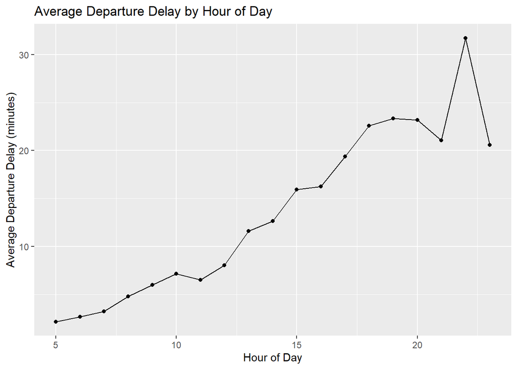

```r
average_delay_by_hour <- merged %>%
      group_by(hour) %>%
      summarize(avg_dep_delay = mean(dep_delay, na.rm = TRUE))

ggplot(average_delay_by_hour, aes(x = hour, y = avg_dep_delay)) +
      geom_line() +
      geom_point() +
      labs(title = "Average Departure Delay by Hour of Day",
           x = "Hour of Day",
           y = "Average Departure Delay (minutes)")
```

```r
flights_hourly <- merged %>%
  group_by(hour) %>%
  summarize(
    total_flights = n(),
    dc_count = sum(late),
    dc_percentage = (dc_count / total_flights) * 100)
flights_hourly
```

```
## # A tibble: 19 × 4
##     hour total_flights dc_count dc_percentage
##    <dbl>         <int>    <int>         <dbl>
##  1     5           833      277          33.3
##  2     6          5305     1610          30.3
##  3     7          4383     1329          30.3
##  4     8          4416     1445          32.7
##  5     9          3079     1121          36.4
##  6    10          2976     1115          37.5
##  7    11          2657      965          36.3
##  8    12          3045     1110          36.5
##  9    13          3263     1638          50.2
## 10    14          3885     2084          53.6
## 11    15          4612     2601          56.4
## 12    16          2707     1510          55.8
## 13    17          4802     2906          60.5
## 14    18          3884     2490          64.1
## 15    19          2802     1810          64.6
## 16    20          3833     2346          61.2
## 17    21          1160      709          61.1
## 18    22            11        7          63.6
## 19    23             9        6          66.7
```

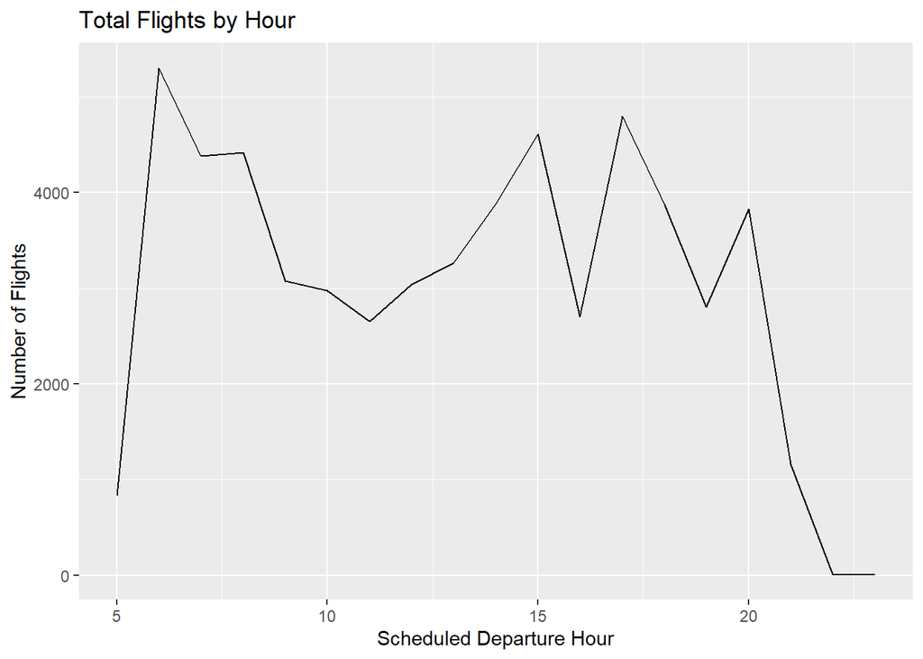

```r
ggplot(data = flights_hourly, aes(x = hour, y = total_flights)) +
  geom_line() +
  labs(title = "Total Flights by Hour",
       x = "Scheduled Departure Hour",
       y = "Number of Flights")
```

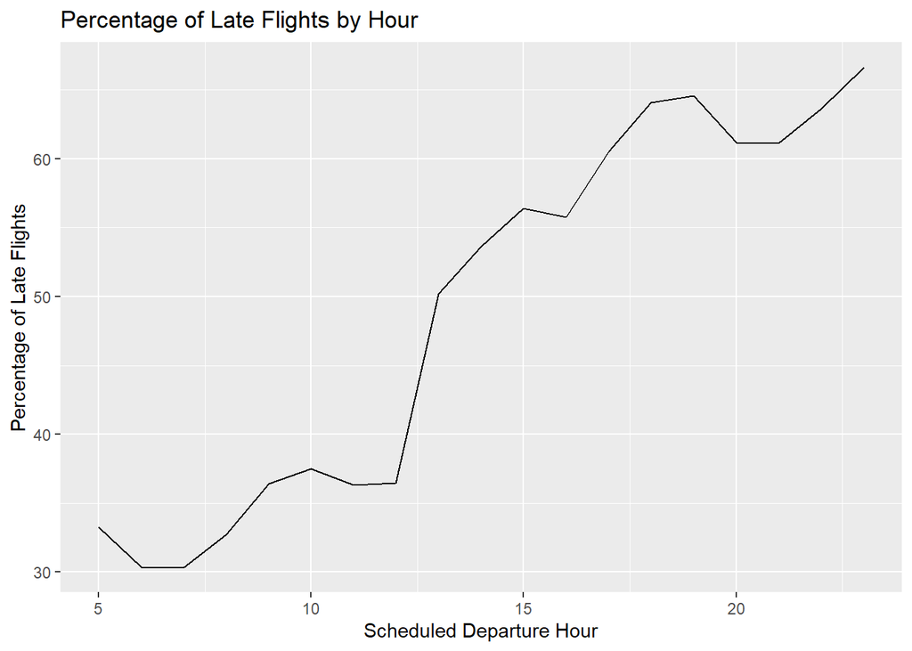

```r
ggplot(data = flights_hourly, aes(x = hour, y = dc_percentage)) +
  geom_line() +
  labs(title = "Percentage of Late Flights by Hour",
       x = "Scheduled Departure Hour",
       y = "Percentage of Late Flights")
```

#### There is an inflection point around noon so we will split the data between morning and evening.

### Time of Day Permutation Test

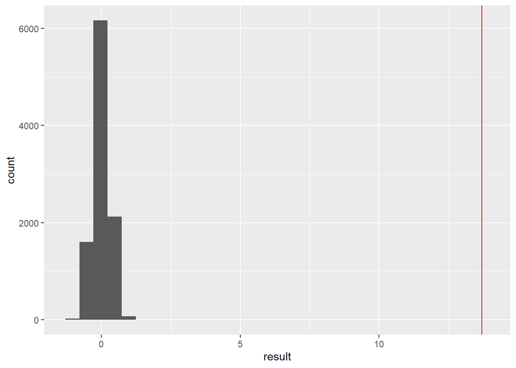

```r
## Create a morning and evening label, set late variable
merged<-merged%>%
  mutate(morning = dep_time <1200)%>%
  mutate(evening = dep_time>=1200)%>%
  mutate(adj_dep_delay = ifelse(merged$dep_delay>0,dep_delay,0))

#calculate and store the observed difference in the sample
observed <- mean(merged$adj_dep_delay[merged$evening==TRUE]) -
mean(merged$adj_dep_delay[merged$morning==TRUE])

#N = number of simulations we will use
N <- 10^4-1

#sample.size = the number of observations in our sample (Morning+Evening)
sample.size = nrow(merged)

#group.1.size = the number of observations in the first group
group.1.size = nrow(merged[merged$evening == TRUE,])

#N = number of simulations we will use
N <- 10^4-1

#sample.size = the number of observations in our sample (Morning+Evening)
sample.size = nrow(merged)

#group.1.size = the number of observations in the first group
group.1.size = nrow(merged[merged$morning == TRUE,])

#create a blank vector to store the simulation results
result <- numeric(N)

#use a for loop to cycle through values of i ranging from 1 to N
for(i in 1:N)
{
  index <- sample(sample.size, size=group.1.size, replace = FALSE)

  #calculate and store the difference in
  #mean dep_delay between the index and non-index groups
  result[i] <- mean(merged$adj_dep_delay[index]) - mean(merged$adj_dep_delay[-index])
}

#plot a histogram of the simulated differences
#add a vertical line at the observed difference
ggplot(data=tibble(result), mapping = aes(x=result)) +
  geom_histogram() +
  geom_vline(xintercept = observed, color = "red")
```

```r
#Calculate the p-value
pvalue <- (sum(abs(result) >= abs(observed)) + 1) / (N + 1) ## I used absolute values

observed
```

```
## [1] 13.70876
```

```r
pvalue
```

```
## [1] 1e-04
```

```r
if (pvalue <= 0.05) {
  print("Reject the null hypothesis.")
} else {
  print("Fail to reject the null hypothesis.")
}
```

```
## [1] "Reject the null hypothesis."
```

#### Our permutation tests show a statistically significant difference in terms of the relationship between morning and evening for departure delays.

## Time of year (Jack)

```r
perm_test <- function(group_one,group_two,n_perm = 10^4-1){
#two sided perm test calcuation
#group1, group2: Numeric vectors for the two groups
#n_perm: Number of permutation iterations

  #observed mean difference
  observed <- mean(group_one) - mean(group_two)

  groups_combined <- c(group_one,group_two)

  #sample.size = the number of observations in our sample
  sample.size <- length(groups_combined)

  #group.1.size = the number of observations in the first group
  group.1.size = length(group_one)

  #create a blank vector to store the simulation results
  result <- numeric(n_perm)

  #use a for loop to cycle through values of i ranging from 1 to n_perm
  for(i in 1:n_perm)
  {
    index <- sample(sample.size, size=group.1.size, replace = FALSE)

    result[i] <- mean(groups_combined[index]) -
                mean(groups_combined[-index])
  }

  plot <- ggplot(data = tibble(result), aes(x = result))+
    geom_histogram() +
    geom_vline(xintercept = observed, color = "red")

  print(plot)

  p_value <- (sum(abs(result) >= abs(observed)) + 1) / (N + 1)

  return (p_value)
}
```

#### We will start by analyzing the time of year data to find out if there is a time of the year that is worth investigating.

Analyzing number of late flights by month

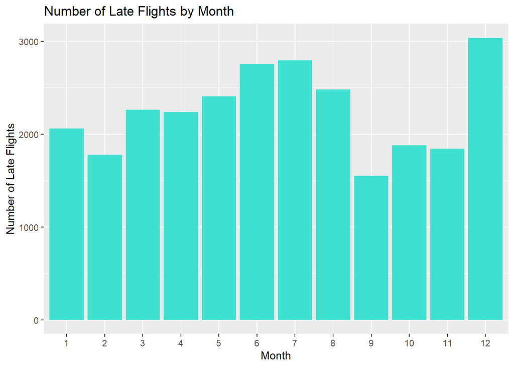

```r
flight_summary <- merged %>%
  group_by(month) %>%
  summarise(
    total_count = n(),                 # Count all flights
    late_count = sum(late == TRUE)     # Count only late flights
  )
merged <- merged %>%
  mutate(dep_delay_adj =ifelse(dep_delay > 0, dep_delay, 0))  #adjust dep_delay to 0 when no delay

late_flights <- merged %>%
  filter(late == TRUE)

ggplot(data = late_flights, aes(x = factor(month))) +

  geom_bar(fill = "turquoise") +

  labs(
    title = "Number of Late Flights by Month",
    x = "Month",
    y = "Number of Late Flights"
  )
```

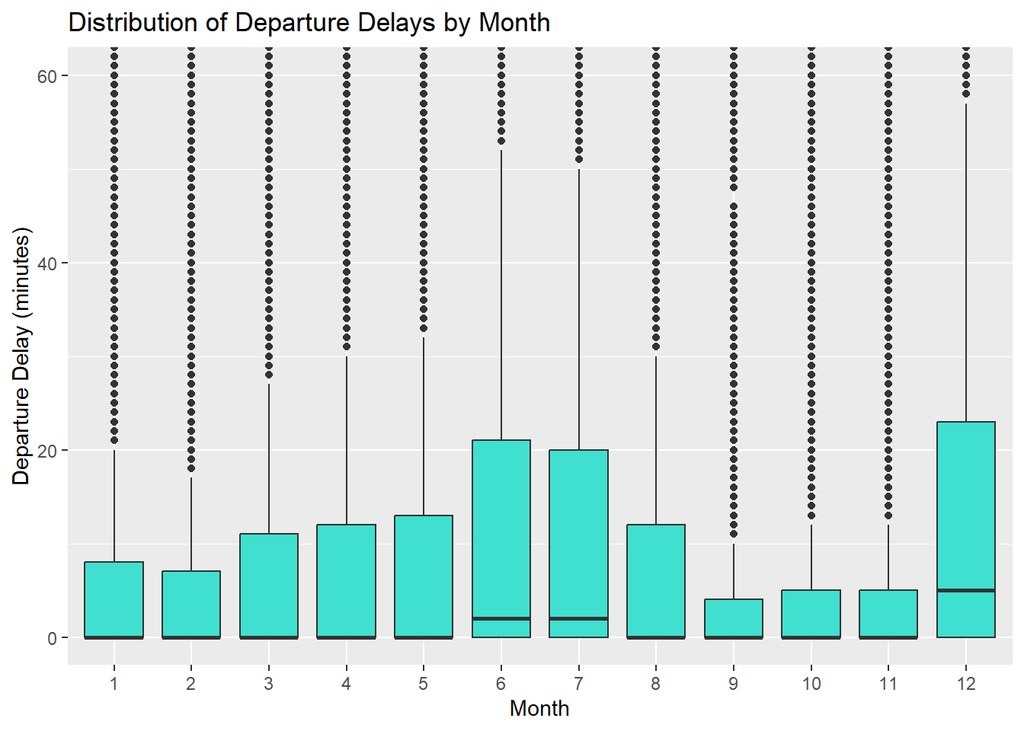

```r
ggplot(data = merged, aes(x = factor(month), y = dep_delay_adj)) +

  geom_boxplot(fill = "turquoise") +

  coord_cartesian(ylim = c(0, 60)) + # Zoom in even more (0 to 60 mins)

  labs(
    title = "Distribution of Departure Delays by Month",
    x = "Month",
    y = "Departure Delay (minutes)"
  )
```

Average delays for a flight per month

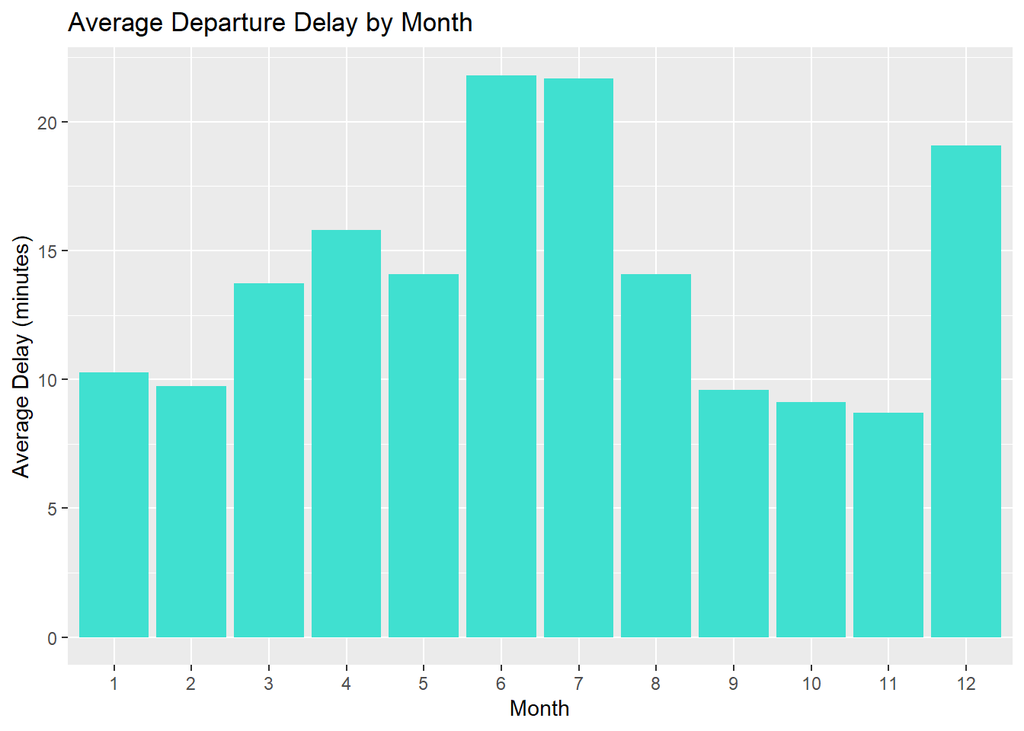

```r
merged <- merged %>%
  mutate(dep_delay_adj =ifelse(dep_delay > 0, dep_delay, 0))  #adjust dep_delay to 0

avg_delay_by_month <- merged %>%
  group_by(month) %>%
  summarise(avg_delay = mean(dep_delay_adj, na.rm = TRUE))

# Then, plot
ggplot(data = avg_delay_by_month, aes(x = factor(month), y = avg_delay)) +
  geom_col(fill = "turquoise") +
  labs(title = "Average Departure Delay by Month",
       x = "Month",
       y = "Average Delay (minutes)")
```

#### We will now define our variables for time of year as “Summer Months” and “Other Months”.

```r
merged <- merged %>%
  mutate(summerLabel = ifelse(month %in% c(6, 7, 8), "Summer Months", "Other Months"))
```

#### With our variables defined, we can now analyze the difference in means between our new variables.

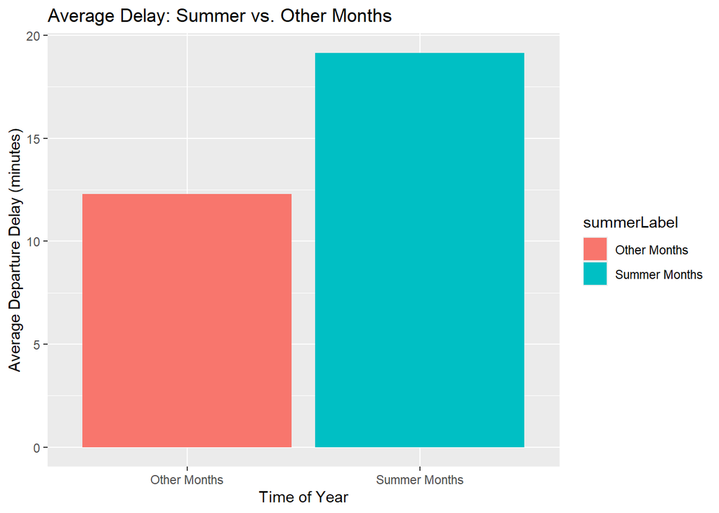

```r
avg_delay_by_summer_and_other <- merged %>%
  group_by(summerLabel) %>%
  summarise(avg_delay = mean(dep_delay_adj, na.rm = TRUE))
ggplot(data = avg_delay_by_summer_and_other, aes(x = summerLabel, y = avg_delay, fill = summerLabel)) +
  geom_col() +
  labs(title = "Average Delay: Summer vs. Other Months",
       x = "Time of Year",
       y = "Average Departure Delay (minutes)")
```

#### Our observed difference of 6.86729 minutes shows a difference that is worth investigating further in a permutation test.

#### Summer late flights permutation test

```r
# Hypothesis
# h.0 = flight_delays.summer == flight_delays.other  (no difference between carrier delays)
# h.alt = flight_delays.winter != flight_delays.other

group1 <- merged$dep_delay_adj[merged$summerLabel == "Summer Months"]
group2 <- merged$dep_delay_adj[merged$summerLabel != "Summer Months"]
pvalue <- perm_test(group1,group2)
```

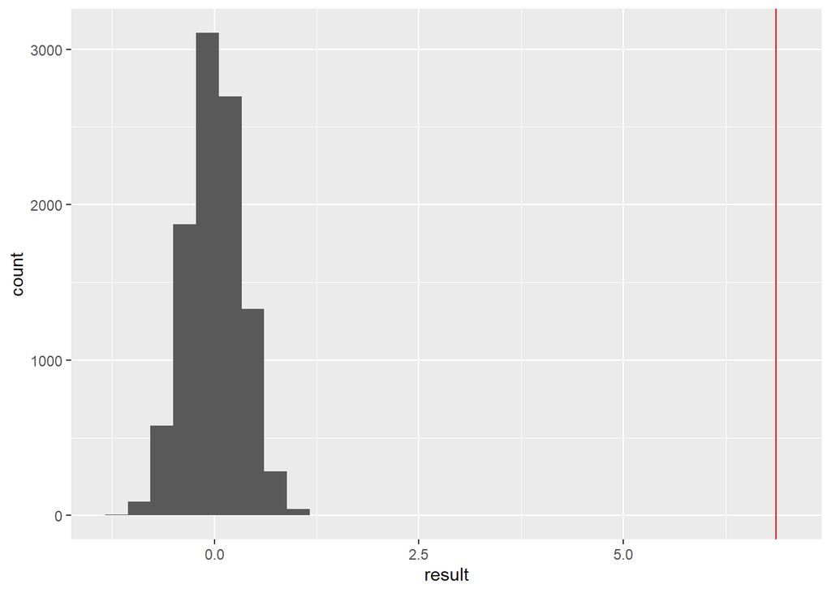

```r
if (pvalue < 0.05) {
  cat("The p-value is", format(pvalue, scientific = FALSE),
      "- Since this is below 0.05, we reject the null hypothesis.\n")
} else {
  cat("The p-value is", format(pvalue, scientific = FALSE),
      "- Since this is above 0.05, we fail to reject the null hypothesis.\n")
}
```

```
## The p-value is 0.0001 - Since this is below 0.05, we reject the null hypothesis.
```

#### Our permutation tests show a statistically significant difference in terms of the relationship between summer months and other months for departure delays.

## Inital Numberical EDA (Cameron)

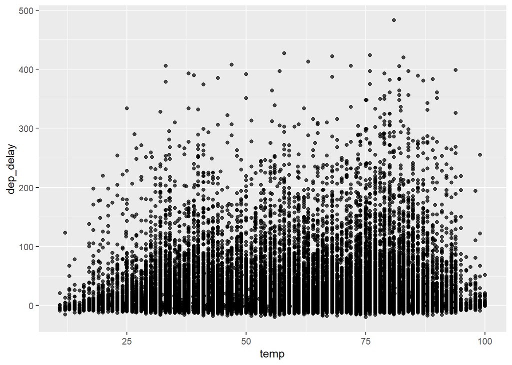

```r
ggplot(data = merged, aes(x = temp, y = dep_delay))+
  geom_point(alpha = 0.7)
```

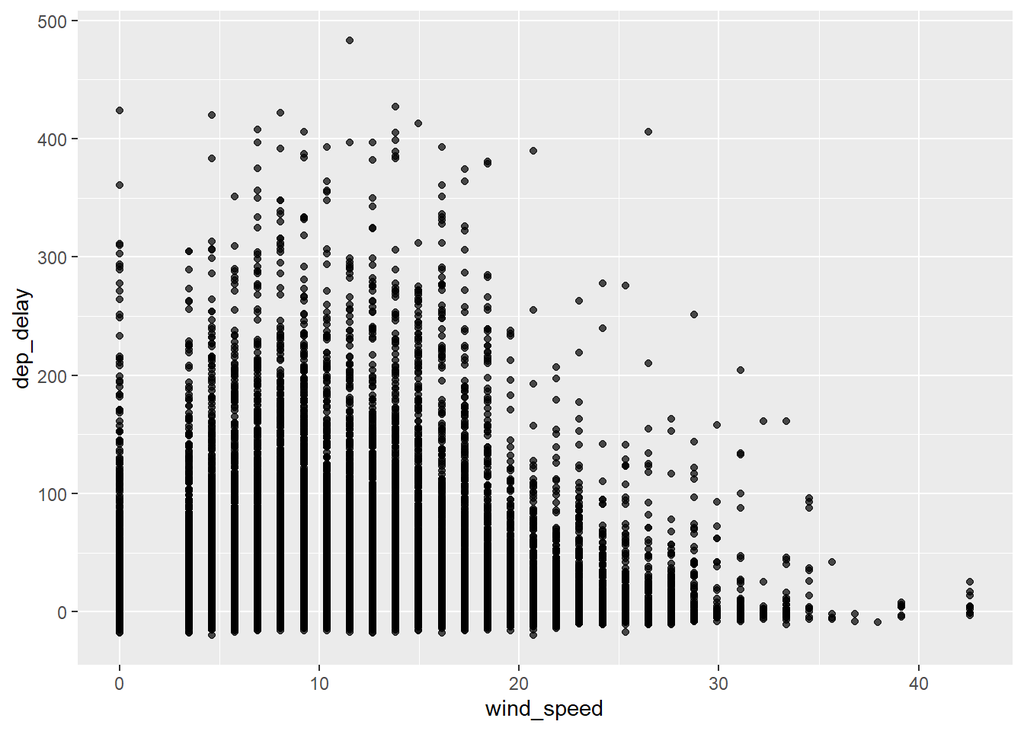

```r
ggplot(data = merged, aes(x = wind_speed, y = dep_delay))+
  geom_point(alpha = 0.7)
```

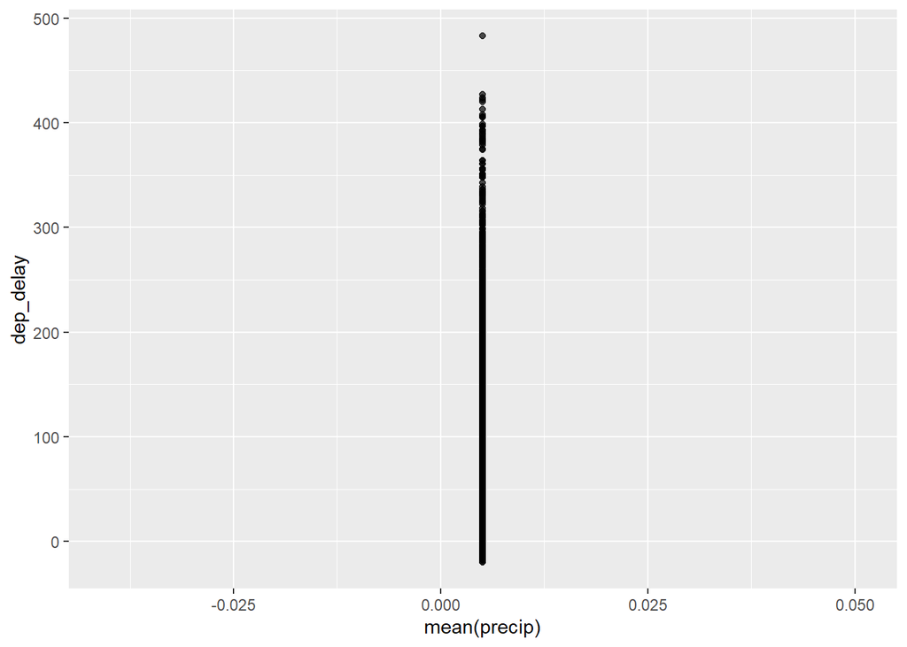

```r
ggplot(data = merged, aes(x = mean(precip), y = dep_delay))+
  geom_point(alpha = 0.7)
```

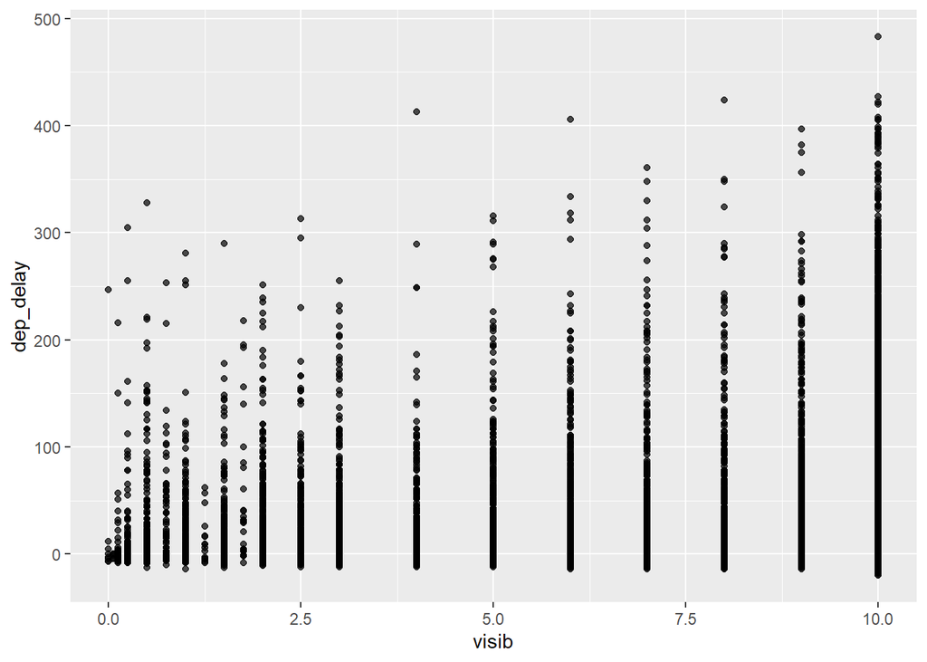

```r
ggplot(data = merged, aes(x = visib, y = dep_delay))+
  geom_point(alpha = 0.7)
```

## Temperature (Jacob)

#### Temperature Summary Statistics

```r
summary_temp <- merged %>%
  summarize(mean = mean(temp, na.rm = TRUE),
            std_dev = sd(temp, na.rm = TRUE),
            min = min(temp, na.rm = TRUE),
            max = max(temp, na.rm = TRUE))
summary_temp
```

```
## # A tibble: 1 × 4
##    mean std_dev   min   max
##   <dbl>   <dbl> <dbl> <dbl>
## 1  57.4    18.4  10.9  100.
```

[figure not shown]

```r
ggplot(data = merged, aes(x = temp, fill = late)) +
  geom_bar() +
  labs(title = "Number of Late Flights by Month",
       x = "Month",
       y = "Number of Late Flights")
```

#### Average Departure Delays vs. Temperature Graph

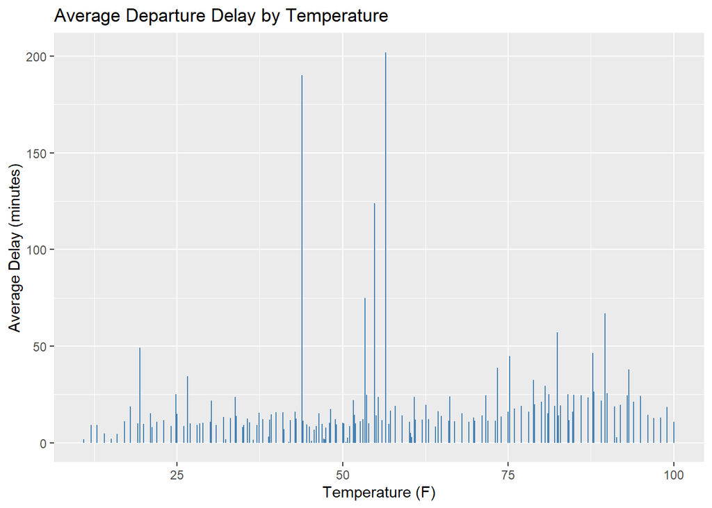

```r
merged <- merged %>%
  mutate(dep_delay_adj = ifelse(dep_delay > 0, dep_delay, 0))

avg_delay_by_temp <- merged %>%
  group_by(temp) %>%
  summarize(avg_delay = mean(dep_delay_adj, na.rm = TRUE))

ggplot(data = avg_delay_by_temp, aes(x = temp, y = avg_delay)) +
  geom_col(fill = "steelblue") +
  labs(title = "Average Departure Delay by Temperature",
       x = "Temperature (F)",
       y = "Average Delay (minutes)")
```

#### Permutation test for relationship between temperature and delays

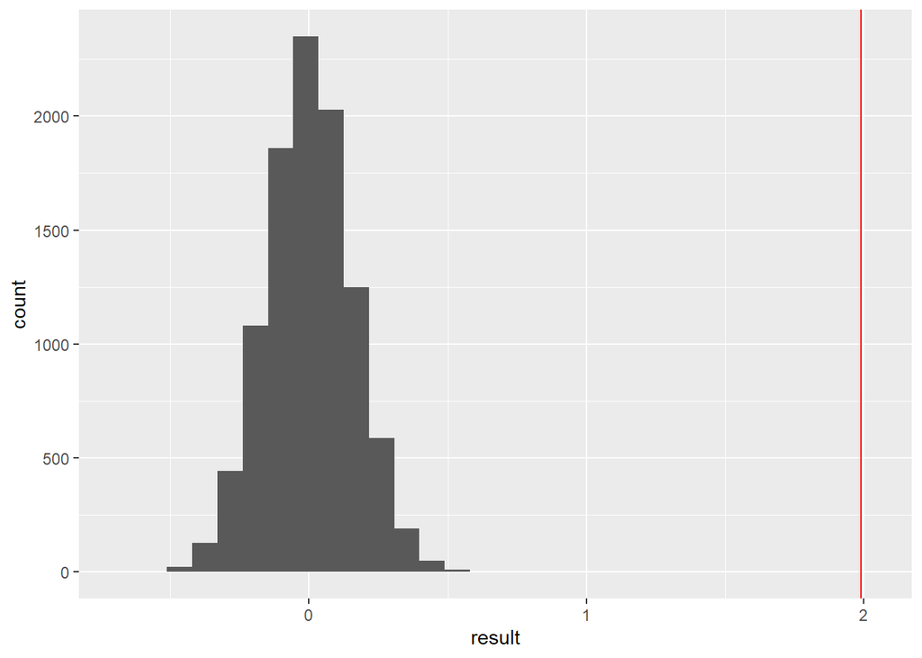

```r
observed <- mean(merged$temp[merged$late == TRUE]) - mean(merged$temp[merged$late == FALSE])

N <- 10^4-1

sample.size = nrow(merged)

group.1.size = nrow(merged[merged$late == TRUE,])

result <- numeric(N)

for (i in 1:N)
{
  index = sample(sample.size, size = group.1.size, replace=FALSE)
  result[i] = mean(merged$temp[index]) - mean(merged$temp[-index])
}

ggplot(data = tibble(result), aes(x = result))+
  geom_histogram() +
  geom_vline(xintercept = observed, color = "red")
```

```r
observed
```

```
## [1] 1.989758
```

```r
2*(sum(result >= observed) +1) / (N+1)
```

```
## [1] 2e-04
```

#### Our permutation tests show a statistically significant difference in terms of the relationship between temperature and departure delays.

## Wind Speed (Jacob)

#### Wind Speed Summary Statistics

```r
summary_wind_speed <- merged %>%
  summarize(mean = mean(wind_speed, na.rm = TRUE),
            std_dev = sd(wind_speed, na.rm = TRUE),
            min = min(wind_speed, na.rm = TRUE),
            max = max(wind_speed, na.rm = TRUE))
summary_wind_speed
```

```
## # A tibble: 1 × 4
##    mean std_dev   min   max
##   <dbl>   <dbl> <dbl> <dbl>
## 1  10.3    5.41     0  42.6
```

#### Histogram of distribution of wind speed

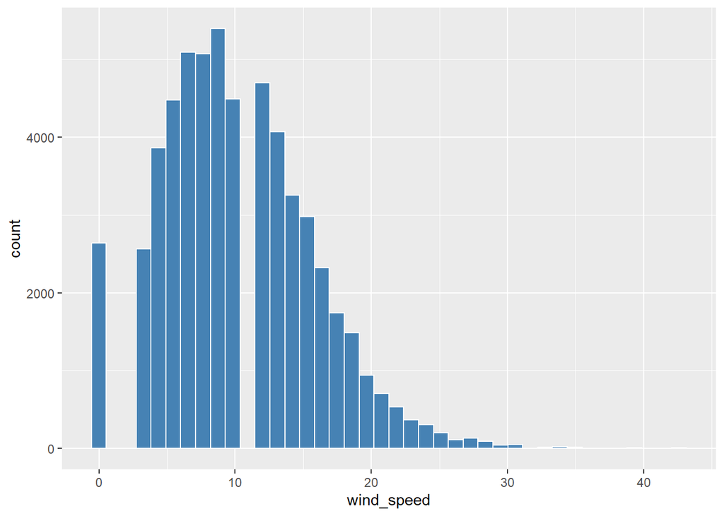

```r
ggplot(data = merged, mapping = aes(x = wind_speed)) +
  geom_histogram(bins=40, color="white", fill="steelblue")
```

#### The initial histogram shows some skew to the right with many of the values falling between 6 and 8 miles per hour, with another jump around 12 miles per hour.

#### We will also use a barplot to examine the average delays compared to wind speed.

#### Average Departure Delays vs. Wind Speed Graph

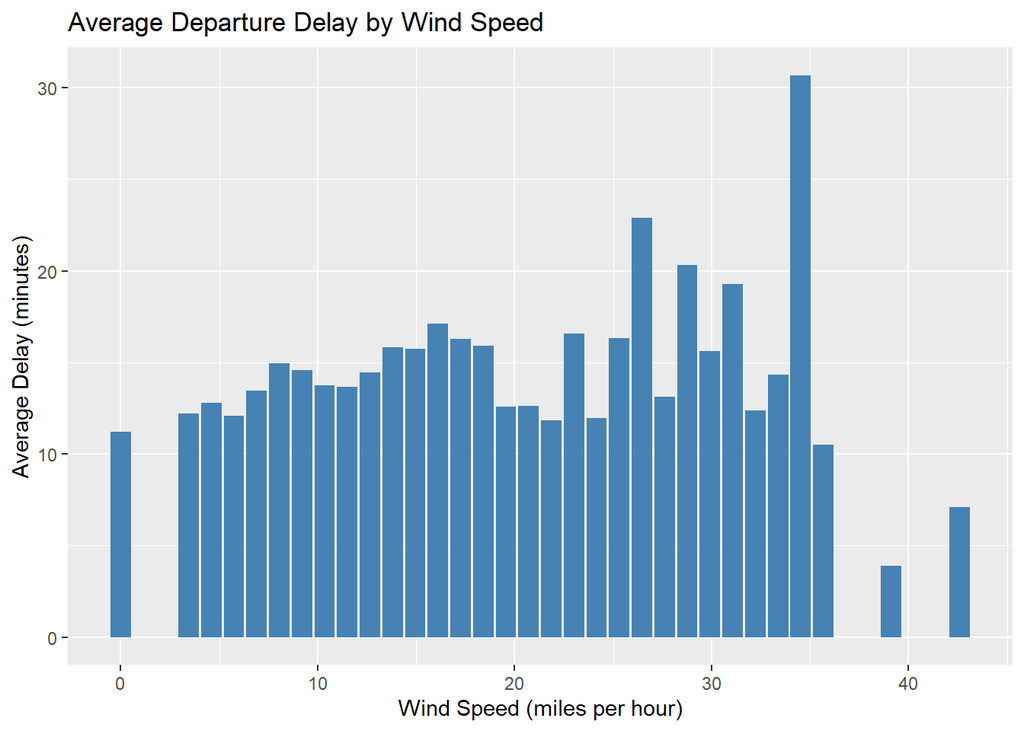

```r
merged <- merged %>%
  mutate(dep_delay_adj = ifelse(dep_delay > 0, dep_delay, 0))

avg_delay_by_wind_speed <- merged %>%
  group_by(wind_speed) %>%
  summarize(avg_delay = mean(dep_delay_adj, na.rm = TRUE))

ggplot(data = avg_delay_by_wind_speed, aes(x = wind_speed, y = avg_delay)) +
  geom_col(fill = "steelblue") +
  labs(title = "Average Departure Delay by Wind Speed",
       x = "Wind Speed (miles per hour)",
       y = "Average Delay (minutes)")
```

#### This relationship looks to be fairly uniform, with a spike in delays around 35 mph, and some outlier data around 39 mph and 40+ mph. These spikes in the data and the outlier data make conducting a permutation test worthwhile.

#### Permutation test for relationship between wind speed and delays

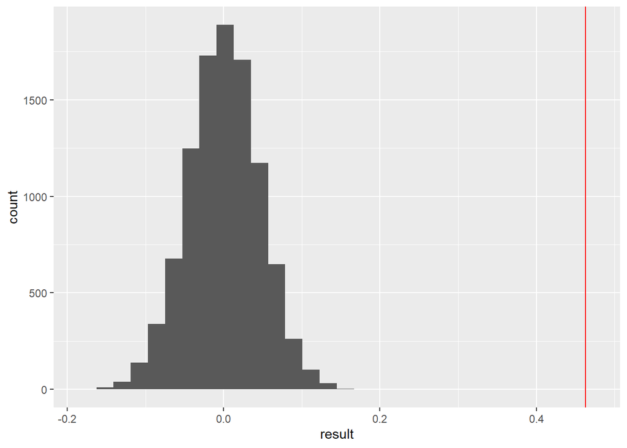

```r
observed <- mean(merged$wind_speed[merged$late == TRUE]) - mean(merged$wind_speed[merged$late == FALSE])

N <- 10^4-1

sample.size = nrow(merged)

group.1.size = nrow(merged[merged$late == TRUE,])

result <- numeric(N)

for (i in 1:N)
{
  index = sample(sample.size, size = group.1.size, replace=FALSE)
  result[i] = mean(merged$wind_speed[index]) - mean(merged$wind_speed[-index])
}

ggplot(data = tibble(result), aes(x = result))+
  geom_histogram() +
  geom_vline(xintercept = observed, color = "red")
```

```r
observed
```

```
## [1] 0.4630571
```

```r
2*(sum(result >= observed) +1) / (N+1)
```

```
## [1] 2e-04
```

#### Our permutation tests show a statistically significant difference in terms of the relationship between wind speed and departure delays.

## Precipitation (Cameron)

#### Our exploratory analysis consisted of analyzing the differences in the dataset of all of the days of the year versus only days of precipitation (precip >0). To do so, we need to mkae a new dataset that only consists of days with precipitation.

```r
merged_precip <- merged %>%
  filter(precip > 0)
glimpse(merged_precip)
```

```
## Rows: 4,034
## Columns: 35
## $ year           <int> 2013, 2013, 2013, 2013, 2013, 2013, 2013, 2013, 2013, 2…
## $ month          <int> 1, 1, 1, 1, 1, 1, 1, 1, 1, 1, 1, 1, 1, 1, 1, 1, 1, 1, 1…
## $ day            <int> 11, 11, 11, 11, 11, 11, 11, 11, 11, 11, 11, 11, 11, 11,…
## $ dep_time       <int> 1457, 1512, 1536, 1653, 1655, 1659, 1709, 1715, 1719, 1…
## $ sched_dep_time <int> 1500, 1505, 1545, 1700, 1705, 1708, 1710, 1719, 1725, 1…
## $ dep_delay      <dbl> -3, 7, -9, -7, -10, -9, -1, -4, -6, 6, 4, 4, 12, 13, -7…
## $ arr_time       <int> 1604, 1823, 1724, 1817, 2009, 2003, 2042, 2011, 2037, 2…
## $ sched_arr_time <int> 1639, 1734, 1744, 1839, 2015, 2024, 2036, 1945, 2050, 2…
## $ arr_delay      <dbl> -35, 49, -20, -22, -6, -21, 6, 26, -13, -7, 3, -6, 14, …
## $ carrier        <chr> "UA", "UA", "UA", "UA", "UA", "UA", "UA", "UA", "UA", "…
## $ flight         <int> 685, 745, 1710, 689, 1259, 250, 1739, 509, 512, 1109, 1…
## $ tailnum        <chr> "N485UA", "N528UA", "N39726", "N813UA", "N14628", "N817…
## $ origin         <chr> "LGA", "LGA", "LGA", "LGA", "LGA", "EWR", "EWR", "LGA",…
```

[output cut: 22 more lines]

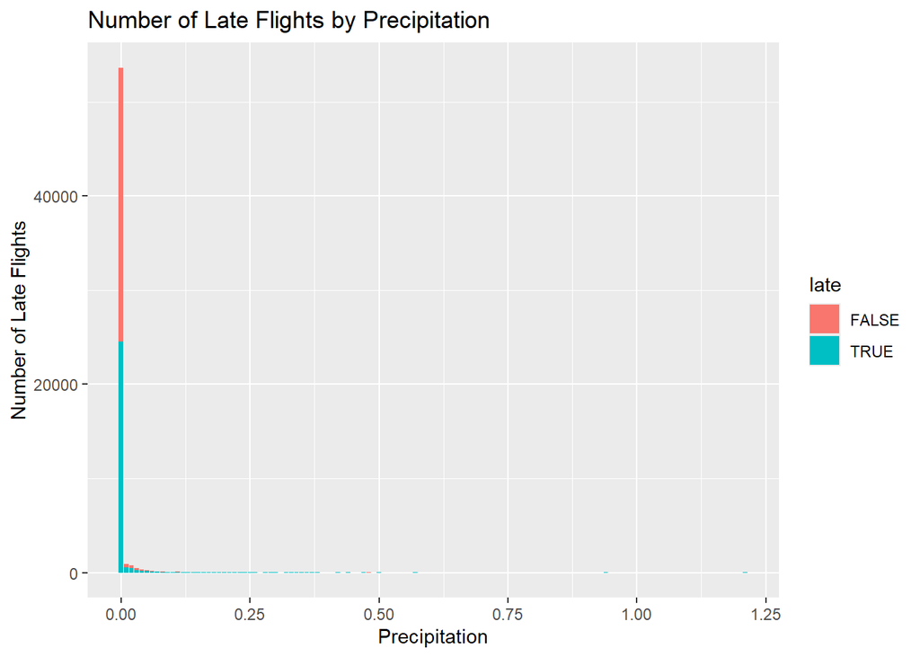

```r
ggplot(data = merged, aes(x = precip, fill = late)) +
  geom_bar() +
  labs(title = "Number of Late Flights by Precipitation",
       x = "Precipitation",
       y = "Number of Late Flights")
```

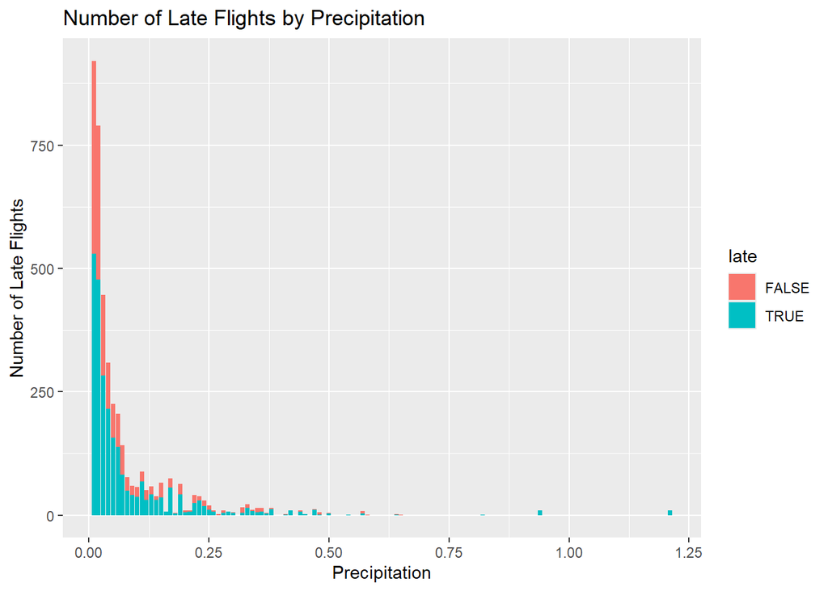

```r
ggplot(data = merged_precip, aes(x = precip, fill = late)) +
  geom_bar() +
  labs(title = "Number of Late Flights by Precipitation",
       x = "Precipitation",
       y = "Number of Late Flights")
```

#### Initially, we can see that a majority of our dataset has days of no precipitation, and that at first glance, there seems to be fewer delays on days with no precipitation.

#### By breaking down our data to days with precipitation only, we can see that there is some more variance in delays that are happeningthat are worth looking into further.

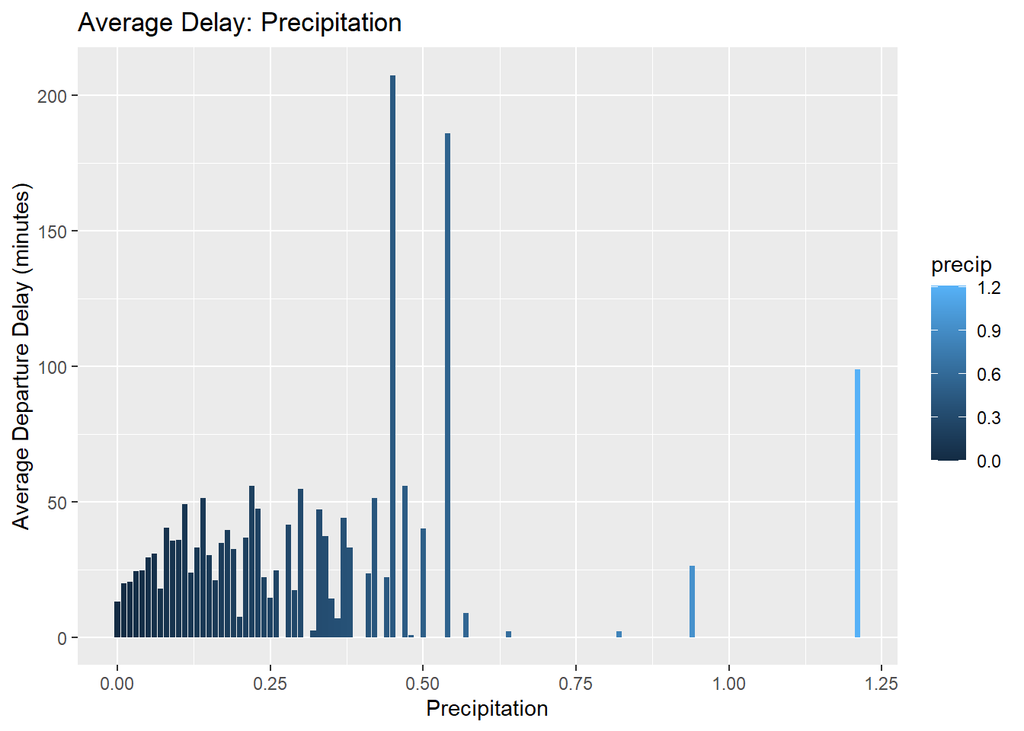

```r
avg_delay_by_precip <- merged %>%
  group_by(precip) %>%
  summarise(avg_delay = mean(dep_delay_adj, na.rm = TRUE))
ggplot(data = avg_delay_by_precip, aes(x = precip, y = avg_delay, fill = precip)) +
  geom_col() +
  labs(title = "Average Delay: Precipitation",
       x = "Precipitation",
       y = "Average Departure Delay (minutes)")
```

#### This bar graph also showsthat there are some extreme delays in certain amounts of precipitation that we can explore further for statistical significance in a permutation test.

#### Precipitation only days permutation test.

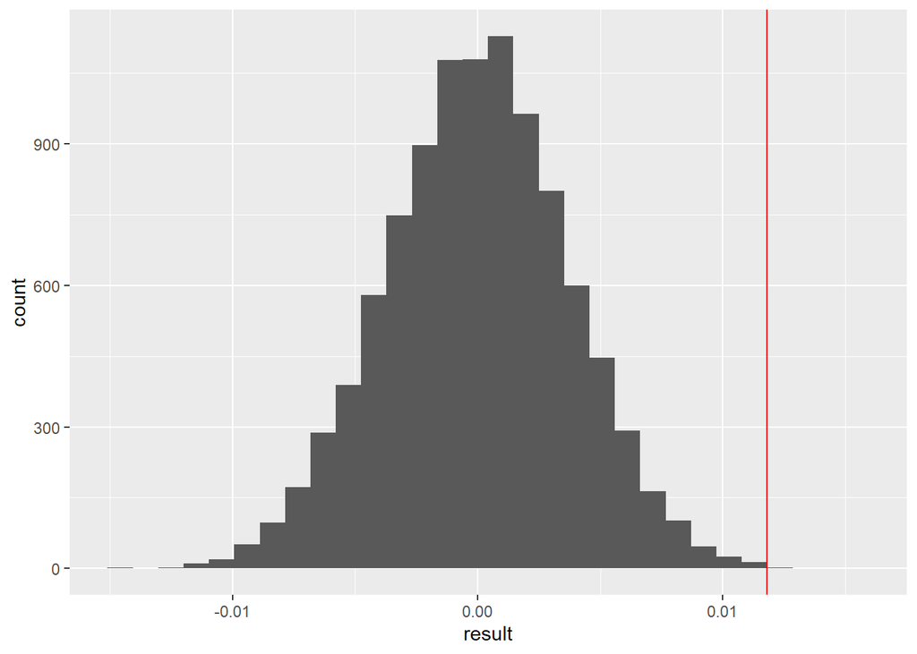

```r
observed <- mean(merged_precip$precip[merged_precip$late == TRUE]) - mean(merged_precip$precip[merged_precip$late == FALSE])

N <- 10^4-1

sample.size = nrow(merged_precip)

group.1.size = nrow(merged_precip[merged_precip$late == TRUE,])

result <- numeric(N)

for (i in 1:N)
{
  index = sample(sample.size, size = group.1.size, replace=FALSE)
  result[i] = mean(merged_precip$precip[index]) - mean(merged_precip$precip[-index])
}

ggplot(data = tibble(result), aes(x = result))+
  geom_histogram() +
  geom_vline(xintercept = observed, color = "red")
```

```r
observed
```

```
## [1] 0.01181451
```

```r
2*(sum(result >= observed) +1) / (N+1)
```

```
## [1] 0.001
```

#### All days precipitation permutation test.

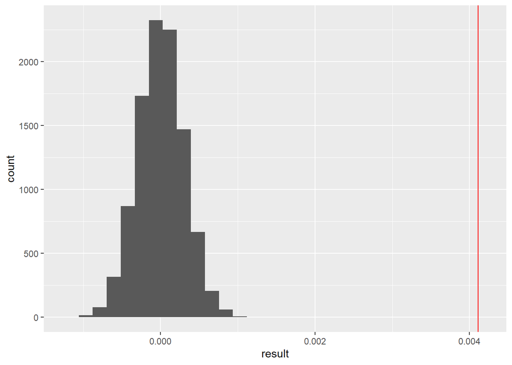

```r
observed <- mean(merged$precip[merged$late == TRUE]) - mean(merged$precip[merged$late == FALSE])

N <- 10^4-1

sample.size = nrow(merged)

group.1.size = nrow(merged[merged$late == TRUE,])

result <- numeric(N)

for (i in 1:N)
{
  index = sample(sample.size, size = group.1.size, replace=FALSE)
  result[i] = mean(merged$precip[index]) - mean(merged$precip[-index])
}

ggplot(data = tibble(result), aes(x = result))+
  geom_histogram() +
  geom_vline(xintercept = observed, color = "red")
```

```r
observed
```

```
## [1] 0.004113635
```

```r
2*(sum(result >= observed) +1) / (N+1)
```

```
## [1] 2e-04
```

#### Our permutation tests show a statistically significant difference in both all days and only precipitation days compared to departure delay.

## Visibility (jack)

#### We will start by analyzing the relationship between visbility and late departure delays through a bar graph.

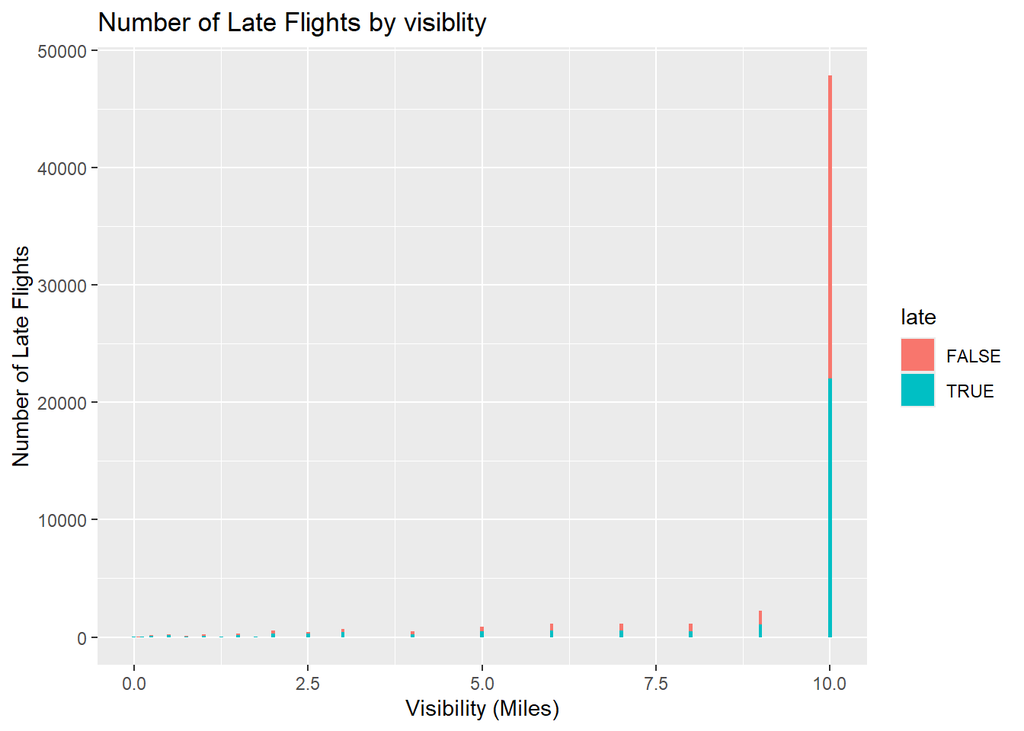

```r
ggplot(data = merged, aes(x = visib, fill = late)) +
  geom_bar() +
  labs(title = "Number of Late Flights by visiblity",
       x = "Visibility (Miles)",
       y = "Number of Late Flights")
```

#### The number of departure delays in terms of visbility seems to be pretty evenly split, so we will need to investigate this further.

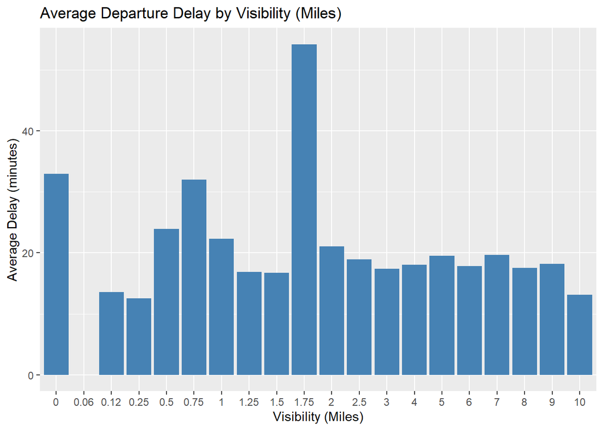

```r
merged <- merged %>%
  mutate(dep_delay_adj =ifelse(dep_delay > 0, dep_delay, 0))  #adjust dep_delay to 0 when no delay

avg_delay_by_visibilty <- merged %>%
  group_by(visib) %>%
  summarise(avg_delay = mean(dep_delay_adj, na.rm = TRUE))

ggplot(data = avg_delay_by_visibilty, aes(x = factor(visib), y = avg_delay)) +
  geom_col(fill = "steelblue") +
  labs(title = "Average Departure Delay by Visibility (Miles)",
       x = "Visibility (Miles)",
       y = "Average Delay (minutes)")
```

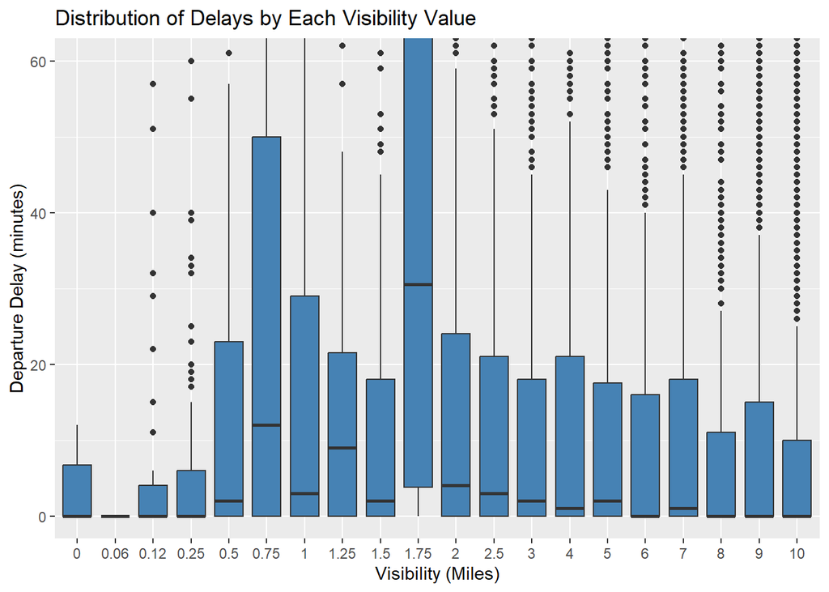

```r
avg_delay_by_visibilty <- merged %>%
  group_by(visib) %>%
  summarise(avg_delay = mean(dep_delay_adj, na.rm = TRUE))


print(ggplot(data = merged %>% filter(visib <= 10),
       aes(x = factor(visib), y = dep_delay_adj)) +

  geom_boxplot(fill = "steelblue") +

  # Zoom in on the most common delays (0-60 min)
  coord_cartesian(ylim = c(0, 60)) +

  labs(title = "Distribution of Delays by Each Visibility Value",
       x = "Visibility (Miles)",
       y = "Departure Delay (minutes)"))
```

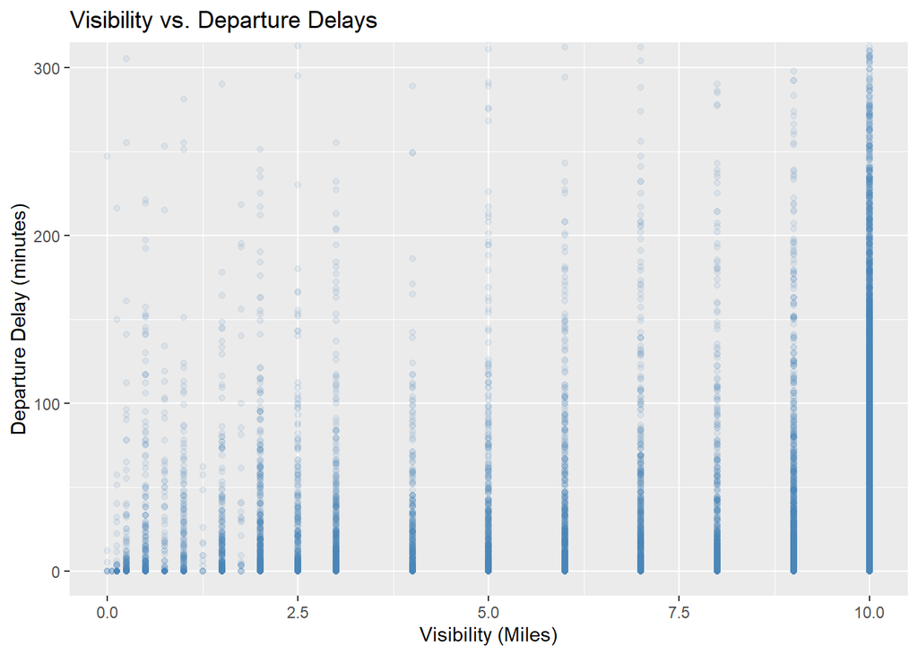

```r
print(ggplot(data = merged %>% filter(visib <= 10),
       aes(x = visib, y = dep_delay_adj)) +

  geom_point(alpha = 0.1, color = "steelblue", size = 1.5) +

  # Zoom in on the most important data range
  coord_cartesian(ylim = c(0, 300)) +

  labs(
    title = "Visibility vs. Departure Delays",
    x = "Visibility (Miles)",
    y = "Departure Delay (minutes)"
  ))
```

```r
merged <- merged %>%
  mutate(visibilityLabel = ifelse(visib <=3, "Low Visibility", "Normal Visibility"))
```

```r
avg_delay_by_visibility <- merged %>%
  group_by(visibilityLabel) %>%
  summarise(avg_delay = mean(dep_delay_adj, na.rm = TRUE))
avg_delay_by_visibility
```

```
## # A tibble: 2 × 2
##   visibilityLabel   avg_delay
##   <chr>                 <dbl>
## 1 Low Visibility         19.6
## 2 Normal Visibility      13.8
```

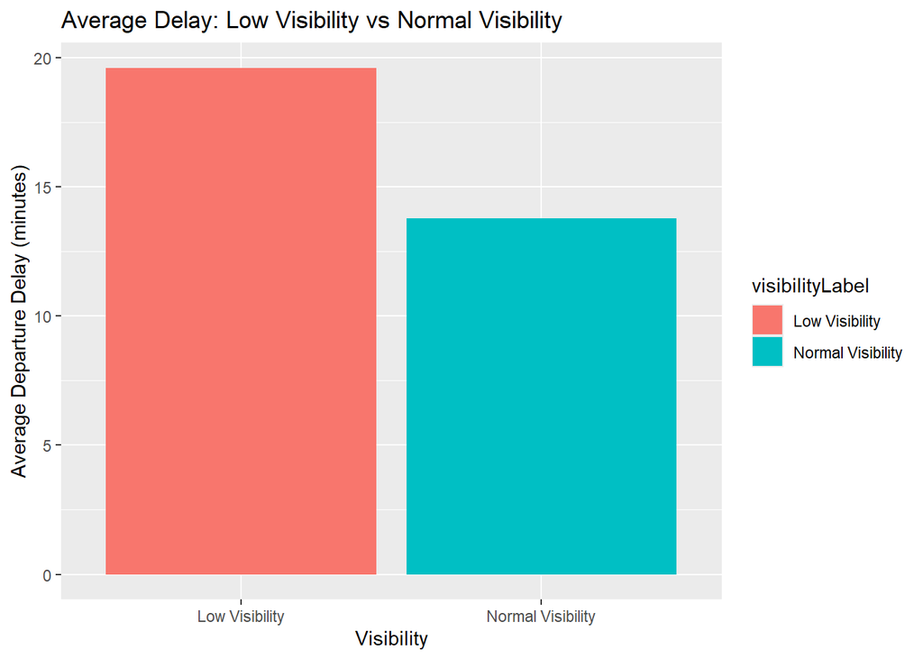

```r
ggplot(data = avg_delay_by_visibility, aes(x = visibilityLabel, y = avg_delay, fill = visibilityLabel)) +
  geom_col() +
  labs(title = "Average Delay: Low Visibility vs Normal Visibility",
       x = "Visibility",
       y = "Average Departure Delay (minutes)")
```

#### The observed difference in means being 5.82023 for low visibility vs. normal visbility gives us justification for looking into a permutation test.

#### Visibility flights permutation test

```r
# Hypothesis
# h.0 = flight_delays.low_visibility == flight_delays.normal_visibility  (no difference between carrier delays)
# h.alt = flight_delays.low_visibility != flight_delays.normal_visibility

group1 <- merged$dep_delay_adj[merged$visibilityLabel == "Low Visibility"]
group2 <- merged$dep_delay_adj[merged$visibilityLabel != "Low Visibility"]

pvalue <- perm_test(group1,group2)
```

[figure not shown]

```r
if (pvalue < 0.05) {
  cat("The p-value is", format(pvalue, scientific = FALSE),
      "- Since this is below 0.05, we reject the null hypothesis.\n")
} else {
  cat("The p-value is", format(pvalue, scientific = FALSE),
      "- Since this is above 0.05, we fail to reject the null hypothesis.\n")
}
```

```
## The p-value is 0.0001 - Since this is below 0.05, we reject the null hypothesis.
```

#### Our permutation test shows a statistically significant difference between low and normal visbility.